# R Notebook

```r
library(rpart)
library(rpart.plot)
library(tidyverse)
library(GGally)
library(modelr)
library(yardstick)
titanic_set <- read_csv('data/titanic_decision_tree_data.csv')
shuffle_index <- sample(1:nrow(titanic_set))

titanic_set <- titanic_set[shuffle_index, ]
```

1.1

```r
titanic_clean <- titanic_set %>%
  filter(survived %in% c(0,1)) %>%
# Convert to factor level
    mutate(sex = as.factor(sex),
           age_status = as.factor(if_else(age <= 16, "child", "adult")),
         class = factor(pclass, levels = c(3,2,1), labels = c("Lower", "Middle", "Upper")),
           survived_flag = factor(survived, levels = c(0,1), labels = c("No", "Yes")),
           port_embarkation = as.factor(embarked)) %>%
  select(sex, age_status, class, port_embarkation, sib_sp, parch, survived_flag) %>%
  na.omit()
```

1.2

A little tricky to read but should be ok without a split. Female/Male looks good for prediction, Adult Child, and so does the class.

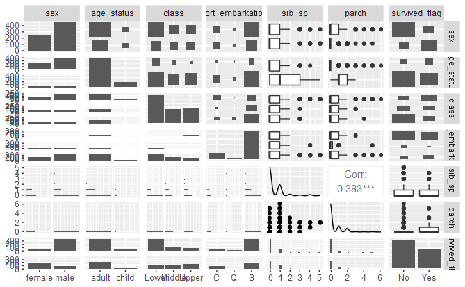

```r
ggpairs(titanic_clean)
```

```r
n_data <- nrow(titanic_clean)


test_index <- sample(1:n_data, size = n_data*0.2)


titanic_test  <- slice(titanic_clean, test_index)


titanic_train <- slice(titanic_clean, -test_index)

titanic_test %>%
 janitor::tabyl(survived_flag)
```

[output not shown]

```r
titanic_train %>%
 janitor::tabyl(survived_flag)
```

```
 survived_flag   n   percent
            No 336 0.5894737
           Yes 234 0.4105263
```

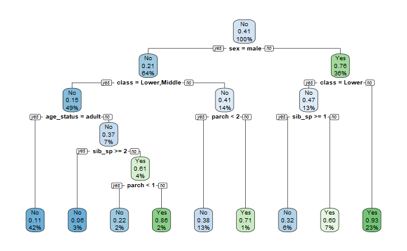

```r
titanic_part <- rpart(
  formula = survived_flag ~ .,
  data = titanic_train,
  method = 'class'
)

rpart.plot(titanic_part,
           yesno = 2,
           fallen.leaves = TRUE,
           faclen = 6,
           digits = 2)
```

Looking at the root node considering everything you were more likely to have died with the chance at survival at .4 Moving down the tree (or up) If you were male you had even worse odds with a likelihood at survival of .2 But if you weren’t, you were more likely to have survived. For both male and female not being in the lower classes further improved the likelihood of survival. Not having siblings increased the likelihood of survival in both branches and so did having parents/children aboard. From the tree highest likelihood of survival was females in the upper class of the ship and the least likely was male children in the lower class decks with 2 or more siblings.

```r
titanic_test_pred <- titanic_test %>%
  add_predictions(titanic_part, type = 'class')
```

```r
titanic_test_pred %>%
  select(sex, class, sib_sp, age_status, survived_flag, pred)
```

| sex | class | sib_sp | age_status | survived_flag | pred |
| --- | --- | --- | --- | --- | --- |
| male | Lower | 1 | adult | No | No |
| female | Upper | 1 | adult | Yes | Yes |
| female | Lower | 0 | child | Yes | Yes |
| female | Upper | 1 | adult | Yes | Yes |
| male | Middle | 2 | child | Yes | No |
| male | Lower | 0 | adult | No | No |
| female | Lower | 0 | adult | Yes | Yes |
| female | Lower | 0 | adult | No | Yes |
| male | Lower | 0 | adult | No | No |
| male | Middle | 0 | adult | No | No |

[output cut: 132 more lines]

```r
conf_mat <- titanic_test_pred %>%
              conf_mat(truth = survived_flag, estimate = pred)

conf_mat
```

```
          Truth
Prediction No Yes
       No  74  21
       Yes 13  34
```

So the model is highly sensitive ? Still struggle with knowing which is which

ok it was

| .metric | .estimator | .estimate |
| --- | --- | --- |
| sensitivity | binary | 0.8505747 |